# Regression Models Course Project

Created by Eduardo Ferreira - 2014

Abstract

In this project, a data set of a collection of cars will be analysis, especially the relationship between a set of variables and miles per gallon. Particularly, following question will be answered by the data set:

We would like to know if automatic is better ou not than manual transmission for MPG. We would like to know how different is the MPG between automatc and manual transmission;

Briefly, cars with a manual transmission have a slightly better than automatic for MPG, but this different is statistical insignificant.

Analysis

mtcars is a data frame with 32 observations on 11 variables. Frist, using scatter plot matrices to show the data, as Figure 1 in appendix. Here you can see the bivariate relationship among all the variables. And the variable of mtcars$vs and mtcars$am should be category variables. So fix it.

```r
mtcars$vs <- as.factor(mtcars$vs)
mtcars$am <- as.factor(mtcars$am)
```

We mainly focus on the relationship between variables mpg (Miles/(US) gallon) and am (Transmission). Box plot shows that there’s a good separation of groups based on gas mileage.

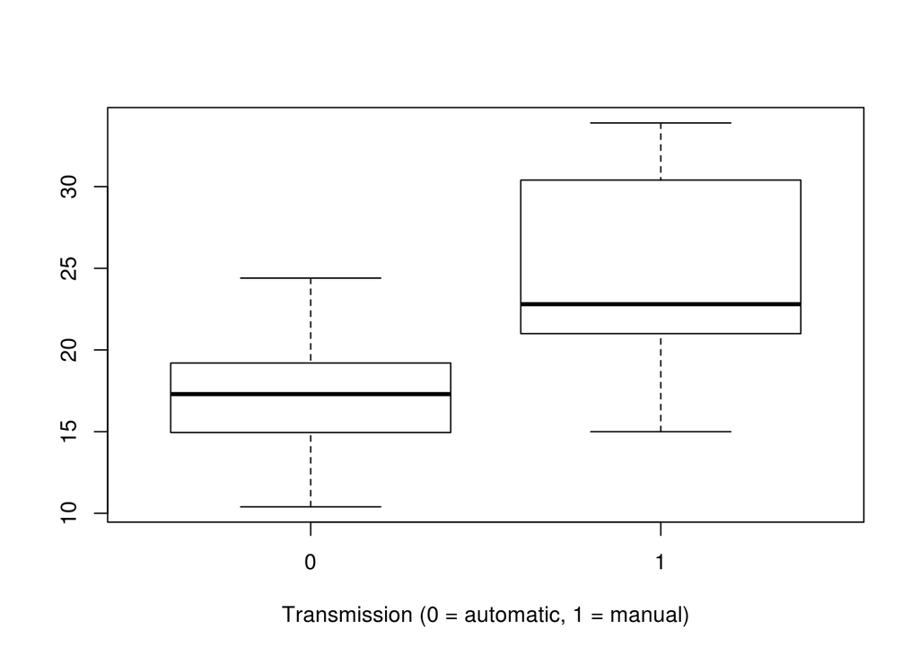

```r
boxplot(mpg ~ am, data = mtcars, xlab = "Transmission (0 = automatic, 1 = manual)")
```

But there are 10 predictor variables in the data set. Some may play bigger role to determination of mpg. An analysis of variance model is performed, as:

```r
analysis <- aov(mpg ~ ., data = mtcars)
summary(analysis)
```

```
##             Df Sum Sq Mean Sq F value Pr(>F)
## cyl          1    818     818  116.42  5e-10 ***
## disp         1     38      38    5.35 0.0309 *
## hp           1      9       9    1.33 0.2610
## drat         1     16      16    2.34 0.1406
## wt           1     77      77   11.03 0.0032 **
## qsec         1      4       4    0.56 0.4617
## vs           1      0       0    0.02 0.8932
## am           1     14      14    2.06 0.1659
## gear         1      1       1    0.14 0.7137
## carb         1      0       0    0.06 0.8122
## Residuals   21    147       7
## ---
## Signif. codes:  0 '***' 0.001 '**' 0.01 '*' 0.05 '.' 0.1 ' ' 1
```

```r
lm <- lm(mpg ~ cyl + disp + wt + drat + am, data = mtcars)
summary(lm)
```

```
##
## Call:
## lm(formula = mpg ~ cyl + disp + wt + drat + am, data = mtcars)
##
## Residuals:
##    Min     1Q Median     3Q    Max
## -4.318 -1.383 -0.473  1.323  6.060
##
## Coefficients:
##             Estimate Std. Error t value Pr(>|t|)
## (Intercept) 41.29638    7.53839    5.48  9.6e-06 ***
## cyl         -1.79400    0.65054   -2.76   0.0105 *
## disp         0.00737    0.01232    0.60   0.5546
## wt          -3.58704    1.21050   -2.96   0.0064 **
## drat        -0.09363    1.54878   -0.06   0.9523
## am1          0.17298    1.53004    0.11   0.9109
## ---
## Signif. codes:  0 '***' 0.001 '**' 0.01 '*' 0.05 '.' 0.1 ' ' 1
##
## Residual standard error: 2.69 on 26 degrees of freedom
## Multiple R-squared:  0.833,  Adjusted R-squared:  0.801
## F-statistic: 25.9 on 5 and 26 DF,  p-value: 2.53e-09
```

Coefficient of drat has a p-value of 0.95226, refine the model as:

```r
lm <- lm(mpg ~ cyl + disp + wt + am, data = mtcars)
summary(lm)
```

```
##
## Call:
## lm(formula = mpg ~ cyl + disp + wt + am, data = mtcars)
##
## Residuals:
##    Min     1Q Median     3Q    Max
## -4.318 -1.362 -0.479  1.354  6.058
##
## Coefficients:
##             Estimate Std. Error t value Pr(>|t|)
## (Intercept)  40.8983     3.6015   11.36  8.7e-12 ***
## cyl          -1.7842     0.6182   -2.89   0.0076 **
## disp          0.0074     0.0121    0.61   0.5451
## wt           -3.5834     1.1865   -3.02   0.0055 **
## am1           0.1291     1.3215    0.10   0.9229
## ---
## Signif. codes:  0 '***' 0.001 '**' 0.01 '*' 0.05 '.' 0.1 ' ' 1
##
## Residual standard error: 2.64 on 27 degrees of freedom
## Multiple R-squared:  0.833,  Adjusted R-squared:  0.808
## F-statistic: 33.6 on 4 and 27 DF,  p-value: 4.04e-10
```

And remove variable disp, now the model is:

```r
lm <- lm(mpg ~ cyl + wt + am, data = mtcars)
summary(lm)
```

```
##
## Call:
## lm(formula = mpg ~ cyl + wt + am, data = mtcars)
##
## Residuals:
##    Min     1Q Median     3Q    Max
## -4.173 -1.534 -0.539  1.586  6.081
##
## Coefficients:
##             Estimate Std. Error t value Pr(>|t|)
## (Intercept)   39.418      2.641   14.92  7.4e-15 ***
## cyl           -1.510      0.422   -3.58   0.0013 **
## wt            -3.125      0.911   -3.43   0.0019 **
## am1            0.176      1.304    0.14   0.8933
## ---
## Signif. codes:  0 '***' 0.001 '**' 0.01 '*' 0.05 '.' 0.1 ' ' 1
##
## Residual standard error: 2.61 on 28 degrees of freedom
## Multiple R-squared:  0.83,   Adjusted R-squared:  0.812
## F-statistic: 45.7 on 3 and 28 DF,  p-value: 6.51e-11
```

To diagnostic the model, we apply the plot() to the object returned by the lm(). There is no discernible pattern found according to upper left graph. The normal Q-Q plot (upper right) indicates the model met the normality assumption. Scale-Location graph (bottom left) shows constant variance assumption are satisfied.

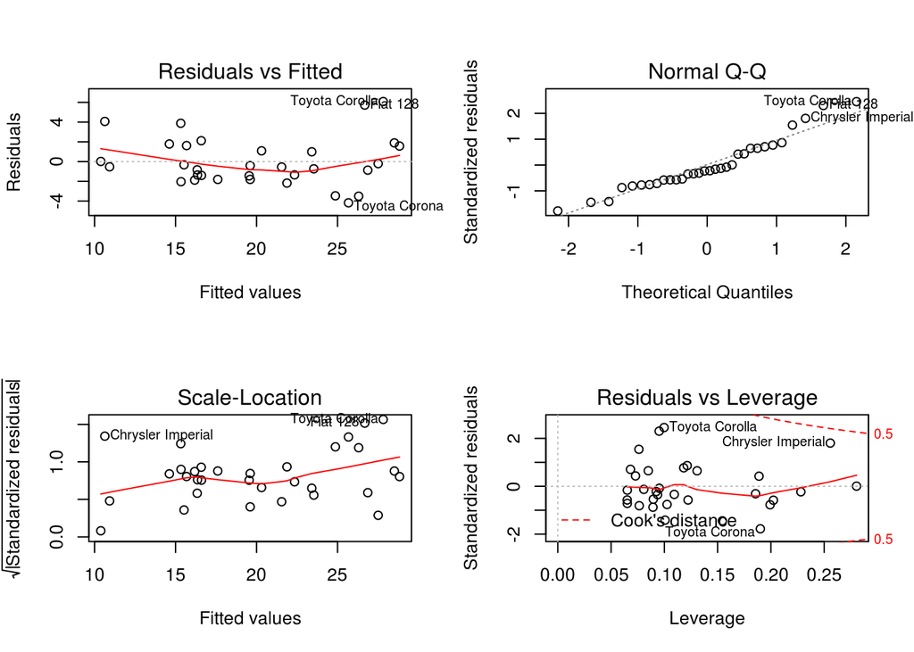

```r
par(mfrow = c(2, 2))
plot(lm)
```

Now we can conclude that weight and number of cylinders play important role to determination of mpg.

**Appendix**

Figure 1

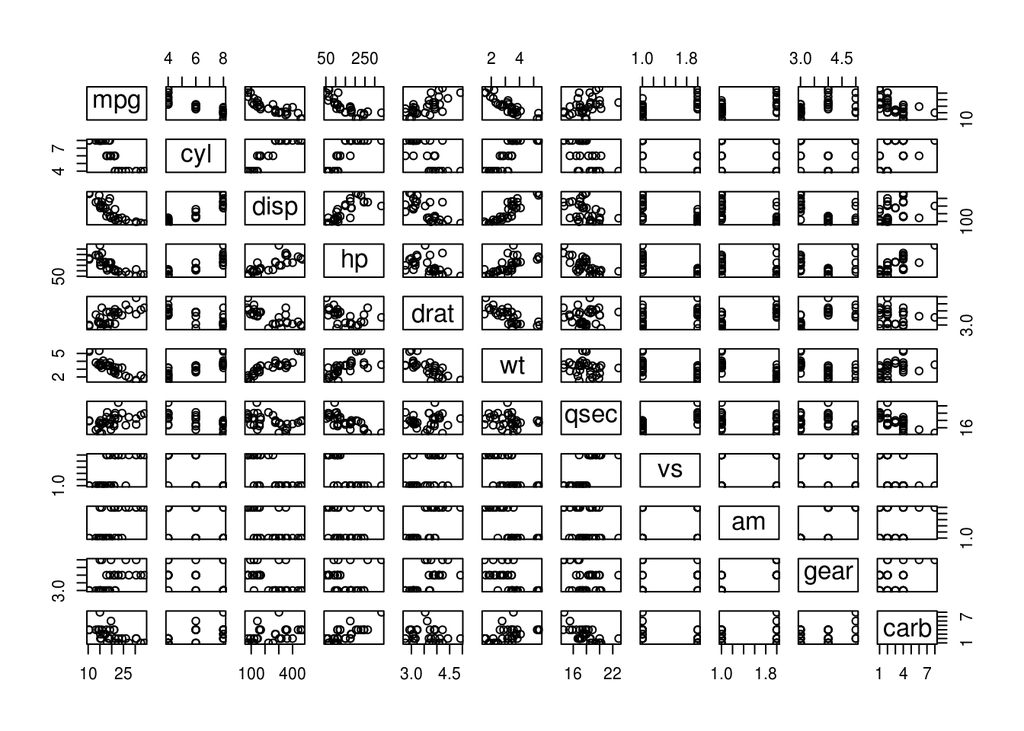

```r
pairs(mtcars)
```